# Non-Diagonal Fall-Back Model

## 3.3 The output from the fit

Here is the fitted spline curve to the number of unmarked fish available in each recovery stratum at the second trap

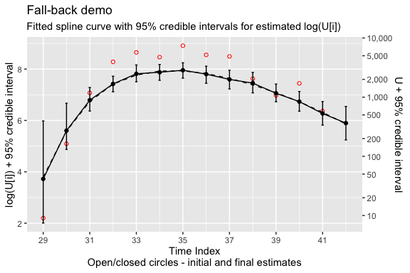

Fitted spline curve

```r
demo.fit$plots$fit.plot
```

The distribution of the posterior sample for the total number unmarked and total abundance that pass the second trap is available. Note this include the sum of the unmarked shown in the previous plot, plus a binomial distribution on the number of marked fish released that pass the second trap.

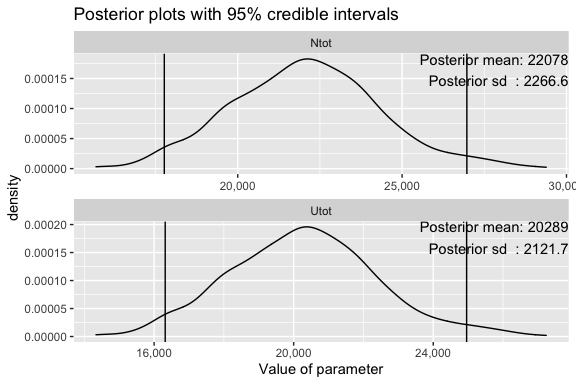

Distribution of posterior samples

```r
demo.fit$plots$post.UNtot.plot
```

A plot of the $logit(P)$ is

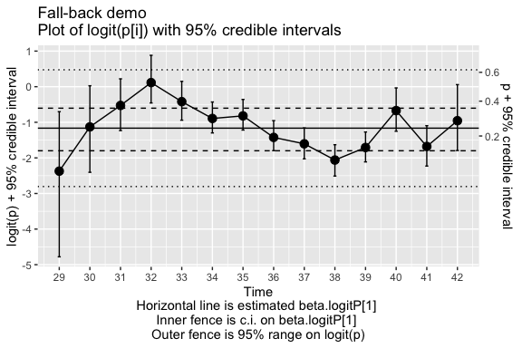

Estimates of logit(p)

```r
demo.fit$plots$logitP.plot
```

In cases where there is little information, $BTSPAS$ has shared information based on the distribution of catchability in the other strata.

A summary of the posterior for each parameter is also available. In particular, here are the summary statistics on the posterior sample for the total number unmarked and total abundance **THAT PASS THE SECOND TRAP**:

```r
demo.fit$summary[ row.names(demo.fit$summary) %in% c("Ntot","Utot"),]
```

```
#>          mean       sd     2.5%     25%     50%     75%    97.5%     Rhat n.eff
#> Ntot 22078.05 2266.638 17766.32 20557.0 22061.0 23548.0 26970.17 1.053470    44
#> Utot 20288.79 2121.686 16318.37 18862.5 20263.5 21646.5 24956.76 1.052413    44
```

This also includes the Rubin-Brooks-Gelman statistic ($Rhat$) on mixing of the chains and the effective sample size of the posterior (after accounting for autocorrelation).

The estimated total abundance is 22,078 (SD 2,267 ) fish.

The estimated distribution function is allowed by vary by release stratum around a common “mean” distribution.

```r
probs <- demo.fit$summary[grepl("movep", row.names(demo.fit$summary)),  ]
round(probs,3)
```

```
#>           mean    sd  2.5%   25%   50%   75% 97.5%  Rhat n.eff
#> movep[1] 0.130 0.029 0.081 0.109 0.127 0.148 0.196 1.001  1500
#> movep[2] 0.513 0.054 0.406 0.478 0.514 0.549 0.618 1.006   350
#> movep[3] 0.205 0.038 0.136 0.178 0.204 0.230 0.281 1.004   480
#> movep[4] 0.085 0.023 0.046 0.068 0.083 0.098 0.135 1.002  1500
#> movep[5] 0.037 0.014 0.014 0.028 0.036 0.046 0.070 1.000  1500
#> movep[6] 0.012 0.008 0.002 0.007 0.011 0.016 0.029 1.006   350
#> movep[7] 0.010 0.007 0.002 0.005 0.008 0.013 0.027 1.005  1300
#> movep[8] 0.007 0.006 0.001 0.004 0.006 0.010 0.022 1.007   320
```

So we expect that about 13% of fish will migrate to the second trap in the day of release; about 51% of fish will migrate to the second trap in the second day after release etc.

The movement for each release stratum varies around this base distribution. It is also possible to see the probability of moving from release stratum $i$ to recovery stratum $j$ by looking at the $Theta[i,j]$ values. Here are the transition probabilities for the first release stratum:

```r
round(demo.fit$summary[ grepl("Theta[1,", row.names(demo.fit$summary),fixed=TRUE),],3)
```

```
#>             mean    sd  2.5%   25%   50%   75% 97.5%  Rhat n.eff
#> Theta[1,1] 0.147 0.090 0.037 0.085 0.126 0.186 0.380 1.000  1500
#> Theta[1,2] 0.491 0.140 0.209 0.396 0.493 0.588 0.747 1.004   650
#> Theta[1,3] 0.204 0.096 0.057 0.129 0.192 0.262 0.426 1.002  1500
#> Theta[1,4] 0.088 0.058 0.015 0.047 0.073 0.115 0.237 1.002  1100
#> Theta[1,5] 0.039 0.031 0.004 0.018 0.031 0.052 0.115 1.000  1500
#> Theta[1,6] 0.013 0.014 0.001 0.004 0.009 0.017 0.047 1.002  1100
#> Theta[1,7] 0.010 0.011 0.000 0.003 0.007 0.013 0.041 1.004  1400
#> Theta[1,8] 0.008 0.009 0.000 0.002 0.005 0.010 0.033 1.005   370
```

The probabilities should also sum to 1 for each release group.

As with the other non-parametric non-diagonal model, you can specify a prior distribution for the movement probabilities.

The sample of the posterior-distribution for the proportion of fish that DO NOT FALL back is

```r
round(demo.fit$summary[ grepl("ma.p", row.names(demo.fit$summary),fixed=TRUE),],3)
```

```
#>   mean     sd   2.5%    25%    50%    75%  97.5%   Rhat  n.eff
#>  0.614  0.057  0.498  0.576  0.614  0.653  0.722  1.049 47.000
```

It is always important to do model assessment before accepting the results from the model fit. Please contact me for details on how to interpret the goodness of fit, trace, and autocorrelation plots.

# 4 References

Bonner, S. J., & Schwarz, C. J. (2011). Smoothing population size estimates for Time-Stratified Mark–Recapture experiments Using Bayesian P-Splines. Biometrics, 67, 1498–1507. https://doi.org/10.1111/j.1541-0420.2011.01599.x

Schwarz, C. J. and Bonner, S. B. (2011). A spline-based capture-mark-recapture model applied to estimating the number of steelhead within the Bulkley River passing the Moricetown Canyon in 2001-2010. Prepared for the B.C. Ministry of Environment.

Schwarz, C. J., & Dempson, J. B. (1994). Mark-recapture estimation of a salmon smolt population. Biometrics, 50, 98–108.